# Forumla 1 Grand Prix Prodium Finish Predictor

### Using Machine Learning Methods to Predict Podium Finishes in Formula 1

**By:** Prithvi Rao  
**UCSB Spring 2026**

[figure not shown]

```python
#imports

import pandas as pd
import numpy as np
import seaborn as sns
import os

import matplotlib.pyplot as plt
import matplotlib.image as mpimg
from matplotlib.offsetbox import OffsetImage, AnnotationBbox
import matplotlib.patches as mpatches

from sklearn.pipeline import make_pipeline
from sklearn.preprocessing import StandardScaler
from sklearn.linear_model import LogisticRegression
from sklearn.discriminant_analysis import LinearDiscriminantAnalysis, QuadraticDiscriminantAnalysis
from sklearn.neighbors import KNeighborsClassifier
from sklearn.tree import DecisionTreeClassifier
from sklearn.ensemble import RandomForestClassifier, GradientBoostingClassifier
from sklearn.metrics import accuracy_score, precision_score, recall_score, f1_score, roc_auc_score
from sklearn.metrics import confusion_matrix
from sklearn.model_selection import StratifiedKFold, GridSearchCV
from sklearn.model_selection import cross_validate

from IPython.display import Image, display
```

```python
pd.set_option("display.max_rows", None)
pd.set_option("display.max_columns", None)
pd.set_option("display.max_colwidth", None)
pd.set_option("display.width", None)
```

## Introduction

The goal of this project is to build a machine learning model that predicts whether a Formula 1 driver will finish on the podium, meaning in the top three, in a Grand Prix. This is therefor a Binary Classification, problem because each driver result is classified as either a podium finish or a non-podium finish.

The data for this project comes from the [Formula 1 World Championship (1950–2024)](https://www.kaggle.com/datasets/rohanrao/formula-1-world-championship-1950-2020) dataset on Kaggle. It includes race results, drivers, lap times, and other relavent race-related data that would be helpfull to train the model to create accurate predictions. This data set includes many csv files, which can be joined with keys like raceID and driverID.

This dataset includes both categorical and numerical variables.

```
Numerical: grid position, finishing position, points, laps completed, qualifying rank, and standings points

Categorical: driver name, constructor/team, circuit, race name, nationality, and race status
```

### How does Forumula 1 Work?

A F1 season is made up of multiple Grand Prix weekends. During this weeking, drivers participate in practice sessions, qualifying, and the main Grand Prix race.

There are three practice sessions where the driver and the team (constructor) prepare the car, but do not determine points or positions.

Qualifying determines a drivers starting position in the Grand Prix. It is brocken up into three sessions:

[output not shown]

The faster the driver, the lower their starting position is (pole position). Sometimes the final starting grid can differ from qualifying order because of penalties or car changes.

The Grand Prix is the main race. Drivers earn championship points based on their finishing position, and the top three finishers are considered podium finishers.

## Exploratory Data Analysis

Before building the models, I explored and cleaned the datasets to better understand the data and which variables can be useful. In this section I will look at the overall structure of the data, check distributions and visualize imporant predictors like grid position, qualifying position, standings, and constructor performance. This helps identify patterns in the data and gives context for which variables may be useful in predicting podium finishes.

### Raw data

```python
circuits = pd.read_csv("../data/circuits.csv")
constructor_results = pd.read_csv("../data/constructor_results.csv")
constructor_standings = pd.read_csv("../data/constructor_standings.csv")
constructors = pd.read_csv("../data/constructors.csv")
driver_standings = pd.read_csv("../data/driver_standings.csv")
drivers = pd.read_csv("../data/drivers.csv")
lap_times = pd.read_csv("../data/lap_times.csv")
pit_stops = pd.read_csv("../data/pit_stops.csv")
qualifying = pd.read_csv("../data/qualifying.csv")
races = pd.read_csv("../data/races.csv")
results = pd.read_csv("../data/results.csv")
seasons = pd.read_csv("../data/seasons.csv")
sprint_results = pd.read_csv("../data/sprint_results.csv")
status = pd.read_csv("../data/status.csv")
```

The race data from the Kaggle dataset is split up into multiple tables with separate files for race results, qualifying results, drivers, constructors, circuits, standings, and race other information. First, lets explore the raw data to see what we are working with.

#### Raw Data summary

Lets iterate through all the tables and see what we are working with.

```python
summary = []

for name, table in tables.items():
    summary.append({
        "table": name,
        "rows": table.shape[0],
        "columns": table.shape[1],
        "missing_values": table.isna().sum().sum()
    })

table_summary = pd.DataFrame(summary)
table_summary
```

|  | table | rows | columns | missing_values |
| --- | --- | --- | --- | --- |
| 0 | circuits | 77 | 9 | 0 |
| 1 | constructor_results | 12625 | 5 | 0 |
| 2 | constructor_standings | 13391 | 7 | 0 |
| 3 | constructors | 212 | 5 | 0 |
| 4 | driver_standings | 34863 | 7 | 0 |
| 5 | drivers | 861 | 9 | 0 |
| 6 | lap_times | 589081 | 6 | 0 |
| 7 | pit_stops | 11371 | 7 | 0 |
| 8 | qualifying | 10494 | 9 | 68 |
| 9 | races | 1125 | 18 | 0 |
| 10 | results | 26759 | 18 | 0 |
| 11 | seasons | 75 | 2 | 0 |
| 12 | sprint_results | 360 | 16 | 0 |
| 13 | status | 139 | 2 | 0 |

Majority of the tables seem to have no missing data. This is good! Qualifying is a very important indicator for driver performance and has 68 values missing, so we need to handle this before training the models.

How many podium and non-podium finihes are in the dataset?

```python
import matplotlib.pyplot as plt
import seaborn as sns

#podium variable from raw results table
results_eda = results.copy()
results_eda["podium"] = results_eda["positionOrder"].apply(
    lambda x: "Podium" if x <= 3 else "Not Podium"
)

#count podium vs non-podium
podium_counts = results_eda["podium"].value_counts().reset_index()
podium_counts.columns = ["finish_type", "count"]

podium_counts
```

|  | finish_type | count |
| --- | --- | --- |
| 0 | Not Podium | 23362 |
| 1 | Podium | 3397 |

Wow! This table shows that this dataset is highly imbalanced. Most observates are non-podium finishes, with ~23k Not Podium and ~3.4k Podium. The model can be correct by predicting non-podium, which isn't useful to predict podium drivers. Therefor accuracy alone can be misleading, metrics like ROC-AUC, precision, recall, and F1-score are also needed

#### Merge dataset into one master dataset

Since the original Formula 1 data is stored across multiple separate tables, merging the relevant files into one master dataset would be beneficial for modeling and analysis. This step is necessary because the outcome variable comes from the race results table, while important predictors such as driver information, constructor information, circuit details, qualifying position, and standings come from different tables.

Each table contains key columns such as `raceId`, `driverId`, `constructorId`, `circuitId`, and `statusId`. I used these keys to merge the tables together, which ensures that each driver, race, constructor, circuit, and race status is matched correctly.

```python
df = results.copy()

df = df.merge(races, on="raceId", how="left", suffixes=("", "_race"))
df = df.merge(drivers, on="driverId", how="left", suffixes=("", "_driver"))
df = df.merge(constructors, on="constructorId", how="left", suffixes=("", "_constructor"))
df = df.merge(circuits, on="circuitId", how="left", suffixes=("", "_circuit"))
df = df.merge(status, on="statusId", how="left")


df = df.rename(columns={
    "name": "race_name",
    "url": "race_url",
    "time_race": "race_time",
    "name_constructor": "constructor_name",
    "nationality_constructor": "constructor_nationality",
    "url_constructor": "constructor_url",
    "name_circuit": "circuit_name",
    "url_circuit": "circuit_url",
    "location": "circuit_location",
    "country": "circuit_country"
})

df.head()
```

|  | resultId | raceId | driverId | constructorId | number | grid | position | positionText | positionOrder | points | laps | time | milliseconds | fastestLap | rank | fastestLapTime | fastestLapSpeed | statusId | year | round | circuitId | race_name | date | race_time | race_url | fp1_date | fp1_time | fp2_date | fp2_time | … |
| --- | --- | --- | --- | --- | --- | --- | --- | --- | --- | --- | --- | --- | --- | --- | --- | --- | --- | --- | --- | --- | --- | --- | --- | --- | --- | --- | --- | --- | --- | --- |
| 0 | 1 | 18 | 1 | 1 | 22 | 1 | 1 | 1 | 1 | 10.0 | 58 | 1:34:50.616 | 5690616 | 39 | 2 | 1:27.452 | 218.300 | 1 | 2008 | 1 | 1 | Australian Grand Prix | 2008-03-16 | 04:30:00 | http://en.wikipedia.org/wiki/2008_Australian_Grand_Prix | \N | \N | \N | \N | … |
| 1 | 2 | 18 | 2 | 2 | 3 | 5 | 2 | 2 | 2 | 8.0 | 58 | +5.478 | 5696094 | 41 | 3 | 1:27.739 | 217.586 | 1 | 2008 | 1 | 1 | Australian Grand Prix | 2008-03-16 | 04:30:00 | http://en.wikipedia.org/wiki/2008_Australian_Grand_Prix | \N | \N | \N | \N | … |
| 2 | 3 | 18 | 3 | 3 | 7 | 7 | 3 | 3 | 3 | 6.0 | 58 | +8.163 | 5698779 | 41 | 5 | 1:28.090 | 216.719 | 1 | 2008 | 1 | 1 | Australian Grand Prix | 2008-03-16 | 04:30:00 | http://en.wikipedia.org/wiki/2008_Australian_Grand_Prix | \N | \N | \N | \N | … |
| 3 | 4 | 18 | 4 | 4 | 5 | 11 | 4 | 4 | 4 | 5.0 | 58 | +17.181 | 5707797 | 58 | 7 | 1:28.603 | 215.464 | 1 | 2008 | 1 | 1 | Australian Grand Prix | 2008-03-16 | 04:30:00 | http://en.wikipedia.org/wiki/2008_Australian_Grand_Prix | \N | \N | \N | \N | … |
| 4 | 5 | 18 | 5 | 1 | 23 | 3 | 5 | 5 | 5 | 4.0 | 58 | +18.014 | 5708630 | 43 | 1 | 1:27.418 | 218.385 | 1 | 2008 | 1 | 1 | Australian Grand Prix | 2008-03-16 | 04:30:00 | http://en.wikipedia.org/wiki/2008_Australian_Grand_Prix | \N | \N | \N | \N | … |

#### Add Qualifying Data

```python
new_qualifying = qualifying[[
    "raceId",
    "driverId",
    "constructorId",
    "position",
    "q1",
    "q2",
    "q3"
]].copy()

new_qualifying = new_qualifying.rename(columns={"position": "qualifying_position"})

df = df.merge(
    new_qualifying,
    on=["raceId", "driverId", "constructorId"],
    how="left"
)
```

#### Add Driver Standing Before Race

```python
new_driver_standings = driver_standings[[
    "raceId",
    "driverId",
    "points",
    "position",
    "wins"
]].copy()

new_driver_standings = new_driver_standings.rename(columns={
    "points": "driver_points_after_race",
    "position": "driver_standing_after_race",
    "wins": "driver_wins_after_race"
})

df = df.merge(
    new_driver_standings,
    on=["raceId", "driverId"],
    how="left"
)
```

#### Add Constructor Standings

```python
new_constructor_standings = constructor_standings[[
    "raceId",
    "constructorId",
    "points",
    "position",
    "wins"
]].copy()

new_constructor_standings = new_constructor_standings.rename(columns={
    "points": "constructor_points_after_race",
    "position": "constructor_standing_after_race",
    "wins": "constructor_wins_after_race"
})

df = df.merge(
    new_constructor_standings,
    on=["raceId", "constructorId"],
    how="left"
)
```

#### Add Constructor Race Results

```python
new_constructor_results = constructor_results[[
    "raceId",
    "constructorId",
    "points"
]].copy()

new_constructor_results = new_constructor_results.rename(columns={
    "points": "constructor_points_race"
})

df = df.merge(
    new_constructor_results,
    on=["raceId", "constructorId"],
    how="left"
)
```

#### Add Pit Stop Data

- number of pit stops
- mean times
- total pit stop time for that race

```python
pit_features = (
    pit_stops
    .groupby(["raceId", "driverId"])
    .agg(
        num_pit_stops=("stop", "count"),
        avg_pit_stop_ms=("milliseconds", "mean"),
        total_pit_stop_ms=("milliseconds", "sum")
    )
    .reset_index()
)

df = df.merge(
    pit_features,
    on=["raceId", "driverId"],
    how="left"
)
```

```python
#fill in missing pit stop data
df["num_pit_stops"] = df["num_pit_stops"].fillna(0)
```

#### Add Lap Times

- avg lap time
- best lap time
- std of lap times

```python
lap_features = (
    lap_times
    .groupby(["raceId", "driverId"])
    .agg(
        avg_lap_ms=("milliseconds", "mean"),
        best_lap_ms=("milliseconds", "min"),
        lap_time_std_ms=("milliseconds", "std")
    )
    .reset_index()
)

df = df.merge(
    lap_features,
    on=["raceId", "driverId"],
    how="left"
)
```

#### Add Sprint Results

```python
new_sprint = sprint_results[[
    "raceId",
    "driverId",
    "constructorId",
    "grid",
    "positionOrder",
    "points"
]].copy()

new_sprint = new_sprint.rename(columns={
    "grid": "sprint_grid",
    "positionOrder": "sprint_positionOrder",
    "points": "sprint_points"
})

df = df.merge(
    new_sprint,
    on=["raceId", "driverId", "constructorId"],
    how="left"
)
```

#### Checking Bahrain 2024 Grand Prix Predictions

[figure not shown]

To make sure the master dataset was merged correctly, lets check 2024 Bahrain Grand Prix as an example race.

```python
races[
    (races["year"] == 2024) & (races["name"].str.contains("Bahrain", case=False, na=False))
]
```

|  | raceId | year | round | circuitId | name | date | time | url | fp1_date | fp1_time | fp2_date | fp2_time | fp3_date | fp3_time | quali_date | quali_time | sprint_date | sprint_time |
| --- | --- | --- | --- | --- | --- | --- | --- | --- | --- | --- | --- | --- | --- | --- | --- | --- | --- | --- |
| 1101 | 1121 | 2024 | 1 | 3 | Bahrain Grand Prix | 2024-03-02 | 15:00:00 | https://en.wikipedia.org/wiki/2024_Bahrain_Grand_Prix | 2024-02-29 | 11:30:00 | 2024-02-29 | 15:00:00 | 2024-03-01 | 12:30:00 | 2024-03-01 | 16:00:00 | \N | \N |

```python
bahrain_2024_race = races[
    (races["year"] == 2024) &
    (races["name"].str.contains("Bahrain", case=False, na=False))
]

bahrain_2024_id = bahrain_2024_race["raceId"].iloc[0]

bahrain_2024_id
```

```
np.int64(1121)
```

```python
bahrain_2024_data = df[df["raceId"] == bahrain_2024_id].copy()

bahrain_2024_clean = bahrain_2024_data[[
    "raceId",
    "year",
    "round",
    "circuit_name",
    "date",
    "driverId",
    "forename",
    "surname",
    "constructorId",
    "constructor_name",
    "grid",
    "positionOrder",
    "positionText",
    "points",
    "status",
    "qualifying_position",
    "driver_points_after_race",
    "driver_standing_after_race",
    "constructor_points_after_race",
    "constructor_standing_after_race"
]].sort_values("positionOrder")

bahrain_2024_clean
```

|  | raceId | year | round | circuit_name | date | driverId | forename | surname | constructorId | constructor_name | grid | positionOrder | positionText | points | status | qualifying_position | driver_points_after_race | driver_standing_after_race | constructor_points_after_race | constructor_standing_after_race |
| --- | --- | --- | --- | --- | --- | --- | --- | --- | --- | --- | --- | --- | --- | --- | --- | --- | --- | --- | --- | --- |
| 26280 | 1121 | 2024 | 1 | Bahrain International Circuit | 2024-03-02 | 830 | Max | Verstappen | 9 | Red Bull | 1 | 1 | 1 | 26.0 | Finished | 1.0 | 26.0 | 1.0 | 44.0 | 1.0 |
| 26281 | 1121 | 2024 | 1 | Bahrain International Circuit | 2024-03-02 | 815 | Sergio | Pérez | 9 | Red Bull | 5 | 2 | 2 | 18.0 | Finished | 5.0 | 18.0 | 2.0 | 44.0 | 1.0 |
| 26282 | 1121 | 2024 | 1 | Bahrain International Circuit | 2024-03-02 | 832 | Carlos | Sainz | 6 | Ferrari | 4 | 3 | 3 | 15.0 | Finished | 4.0 | 15.0 | 3.0 | 27.0 | 2.0 |
| 26283 | 1121 | 2024 | 1 | Bahrain International Circuit | 2024-03-02 | 844 | Charles | Leclerc | 6 | Ferrari | 2 | 4 | 4 | 12.0 | Finished | 2.0 | 12.0 | 4.0 | 27.0 | 2.0 |
| 26284 | 1121 | 2024 | 1 | Bahrain International Circuit | 2024-03-02 | 847 | George | Russell | 131 | Mercedes | 3 | 5 | 5 | 10.0 | Finished | 3.0 | 10.0 | 5.0 | 16.0 | 3.0 |
| 26285 | 1121 | 2024 | 1 | Bahrain International Circuit | 2024-03-02 | 846 | Lando | Norris | 1 | McLaren | 7 | 6 | 6 | 8.0 | Finished | 7.0 | 8.0 | 6.0 | 12.0 | 4.0 |
| 26286 | 1121 | 2024 | 1 | Bahrain International Circuit | 2024-03-02 | 1 | Lewis | Hamilton | 131 | Mercedes | 9 | 7 | 7 | 6.0 | Finished | 9.0 | 6.0 | 7.0 | 16.0 | 3.0 |
| 26287 | 1121 | 2024 | 1 | Bahrain International Circuit | 2024-03-02 | 857 | Oscar | Piastri | 1 | McLaren | 8 | 8 | 8 | 4.0 | Finished | 8.0 | 4.0 | 8.0 | 12.0 | 4.0 |
| 26288 | 1121 | 2024 | 1 | Bahrain International Circuit | 2024-03-02 | 4 | Fernando | Alonso | 117 | Aston Martin | 6 | 9 | 9 | 2.0 | Finished | 6.0 | 2.0 | 9.0 | 3.0 | 5.0 |
| 26289 | 1121 | 2024 | 1 | Bahrain International Circuit | 2024-03-02 | 840 | Lance | Stroll | 117 | Aston Martin | 12 | 10 | 10 | 1.0 | Finished | 12.0 | 1.0 | 10.0 | 3.0 | 5.0 |
| 26290 | 1121 | 2024 | 1 | Bahrain International Circuit | 2024-03-02 | 855 | Guanyu | Zhou | 15 | Sauber | 17 | 11 | 11 | 0.0 | +1 Lap | 17.0 | 0.0 | 11.0 | 0.0 | 6.0 |
| 26291 | 1121 | 2024 | 1 | Bahrain International Circuit | 2024-03-02 | 825 | Kevin | Magnussen | 210 | Haas F1 Team | 15 | 12 | 12 | 0.0 | +1 Lap | 15.0 | 0.0 | 12.0 | 0.0 | 7.0 |
| 26292 | 1121 | 2024 | 1 | Bahrain International Circuit | 2024-03-02 | 817 | Daniel | Ricciardo | 215 | RB F1 Team | 14 | 13 | 13 | 0.0 | +1 Lap | 14.0 | 0.0 | 13.0 | 0.0 | 8.0 |
| 26293 | 1121 | 2024 | 1 | Bahrain International Circuit | 2024-03-02 | 852 | Yuki | Tsunoda | 215 | RB F1 Team | 11 | 14 | 14 | 0.0 | +1 Lap | 11.0 | 0.0 | 14.0 | 0.0 | 8.0 |
| 26294 | 1121 | 2024 | 1 | Bahrain International Circuit | 2024-03-02 | 848 | Alexander | Albon | 3 | Williams | 13 | 15 | 15 | 0.0 | +1 Lap | 13.0 | 0.0 | 15.0 | 0.0 | 9.0 |
| 26295 | 1121 | 2024 | 1 | Bahrain International Circuit | 2024-03-02 | 807 | Nico | Hülkenberg | 210 | Haas F1 Team | 10 | 16 | 16 | 0.0 | +1 Lap | 10.0 | 0.0 | 16.0 | 0.0 | 7.0 |
| 26296 | 1121 | 2024 | 1 | Bahrain International Circuit | 2024-03-02 | 839 | Esteban | Ocon | 214 | Alpine F1 Team | 19 | 17 | 17 | 0.0 | +1 Lap | 19.0 | 0.0 | 17.0 | 0.0 | 10.0 |
| 26297 | 1121 | 2024 | 1 | Bahrain International Circuit | 2024-03-02 | 842 | Pierre | Gasly | 214 | Alpine F1 Team | 20 | 18 | 18 | 0.0 | +1 Lap | 20.0 | 0.0 | 18.0 | 0.0 | 10.0 |
| 26298 | 1121 | 2024 | 1 | Bahrain International Circuit | 2024-03-02 | 822 | Valtteri | Bottas | 15 | Sauber | 16 | 19 | 19 | 0.0 | +1 Lap | 16.0 | 0.0 | 19.0 | 0.0 | 6.0 |
| 26299 | 1121 | 2024 | 1 | Bahrain International Circuit | 2024-03-02 | 858 | Logan | Sargeant | 3 | Williams | 18 | 20 | 20 | 0.0 | +2 Laps | 18.0 | 0.0 | 20.0 | 0.0 | 9.0 |

Looks right! I verified this by cross-referencing the 2024 Bahrain Grand Prix rows in the master dataset with the [official Formula 1 race results page](https://www.formula1.com/en/racing/2024/bahrain) for the 2024 Bahrain Grand Prix.

#### Number of Races Over Time

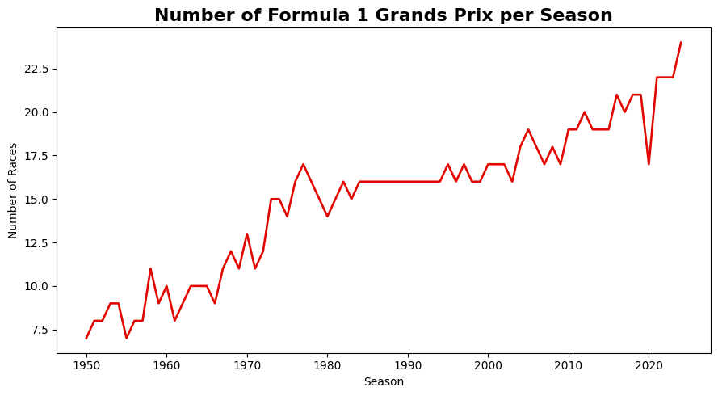

```python
races = pd.read_csv("../data/races.csv")

races_per_year = (
    races
    .groupby("year")
    .size()
    .reset_index(name="num_races")
)

plt.figure(figsize=(9, 5))

sns.lineplot(
    data=races_per_year,
    x="year",
    y="num_races",
    linewidth=1.9,
    color="#E10600"
)

plt.title("Number of Formula 1 Grands Prix per Season", fontsize=16, weight="bold")
plt.xlabel("Season")
plt.ylabel("Number of Races")
plt.tight_layout()
plt.show()
```

This plot shows how the Formula 1 calendar has changed over time. Earlier seasons had fewer races, while modern seasons include more Grands Prix. This matters because recent seasons contribute more observations to the dataset.

The increase in races also show that older seasons may not reflect the same racing environment as modern seasons. The model may learn more useful patterns from more recent season where teams, qualifying structure, and overall competition are more similar to present day.

#### Podium vs non-podium distribution

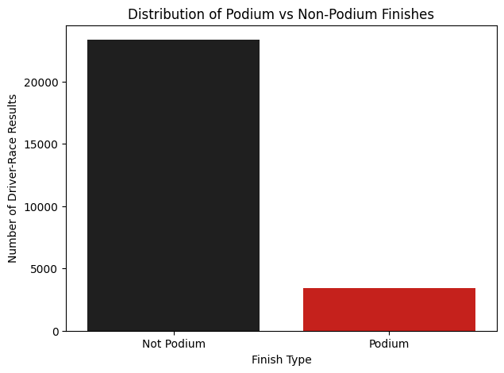

```python
plt.figure(figsize=(7, 5))

sns.barplot(
    data=podium_counts,
    x="finish_type",
    y="count",
    hue="finish_type",
    palette={
        "Not Podium": "#1f1f1f",
        "Podium": "#E10600"
    },
    legend=False
)

plt.title("Distribution of Podium vs Non-Podium Finishes")
plt.xlabel("Finish Type")
plt.ylabel("Number of Driver-Race Results")
plt.show()
```

This plot shows that podium finishes are much less common than non-podium finishes. This class imbalance is expected because only three drivers can finish on the podium. Therefor, accuracy alone is not enough to evaluate the models.

### Podium Rate by Qualifying Position

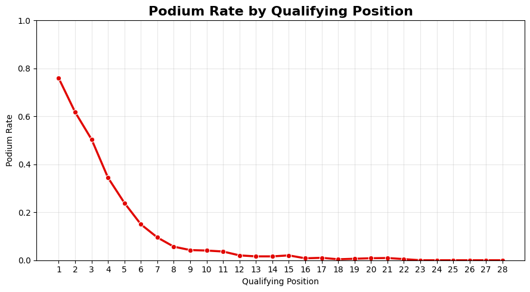

```python
plt.figure(figsize=(9,5))

eda_df = df.copy()

eda_df["podium"] = (eda_df["positionOrder"] <= 3).astype(int)

eda_df["podium_label"] = eda_df["podium"].map({
    1: "Podium",
    0: "Not Podium"
})


qual_podium = (
    eda_df
    .dropna(subset=["qualifying_position"])
    .groupby("qualifying_position")
    .agg(
        starts=("podium", "count"),
        podium_rate=("podium", "mean")
    )
    .reset_index()
)


sns.lineplot(
    data=qual_podium,
    x="qualifying_position",
    y="podium_rate",
    marker="o",
    linewidth=2.5,
    color="#E10600"
)

plt.title("Podium Rate by Qualifying Position", fontsize=16, weight="bold")
plt.xlabel("Qualifying Position")
plt.ylabel("Podium Rate")
plt.xticks(qual_podium["qualifying_position"])
plt.ylim(0, 1)
plt.grid(True, alpha=0.3)
plt.tight_layout()
plt.show()
```

This plot shows that starting position is strongly related to podium finishes. Drivers whose starting position is near the front of the grid have a much higher podium rate than drivers starting further back.

Since podium rate drops sharply after the first few starting positions, qualifying position shuold be used as one of the main predictors in the model. However, race outcomes can still be affected by strategy, reliability, penalties, crashes, weather, and team performance. Therefor qualifying position is important, but it should be combined with other pre-race variables rather than used alone.

### Constructor Podium Rates

```python
team_colors = {
    "Red Bull": "#3671C6",
    "Red Bull Racing": "#3671C6",
    "RB F1 Team": "#6692FF",
    "RB Racing Team": "#6692FF",

    "Ferrari": "#E80020",
    "Mercedes": "#27F4D2",
    "McLaren": "#FF8000",
    "Aston Martin": "#229971",

    "Alpine F1 Team": "#0090FF",
    "Alpine": "#0090FF",
    "Renault": "#FFD800",

    "Williams": "#64C4FF",
    "Sauber": "#52E252",

    "Haas F1 Team": "#B6BABD",
    "Haas": "#B6BABD",

    "AlphaTauri": "#2B4562",
    "Alpha Romeo": "#900000",
    "Alfa Romeo": "#900000",
    "Racing Point": "#F596C8"
}

logo_paths = {
    "Alpine F1 Team": "../assets/team_logos/Alpine.png",
    "Alpine": "../assets/team_logos/Alpine.png",

    "Aston Martin": "../assets/team_logos/Aston Martin.png",
    "Ferrari": "../assets/team_logos/Ferrari.png",

    "Haas F1 Team": "../assets/team_logos/Haas.png",
    "Haas": "../assets/team_logos/Haas.png",

    "McLaren": "../assets/team_logos/McLaren.png",
    "Mercedes": "../assets/team_logos/Mercedes.png",

    "Red Bull": "../assets/team_logos/Red Bull.png",
    "Red Bull Racing": "../assets/team_logos/Red Bull Racing.png",

    "RB F1 Team": "../assets/team_logos/RB Racing Team.png",
    "RB Racing Team": "../assets/team_logos/RB Racing Team.png",

    "Sauber": "../assets/team_logos/Sauber.png",
    "Williams": "../assets/team_logos/Williams.png",

    "AlphaTauri": "../assets/team_logos/AlphaTauri.jpeg",
    "Alfa Romeo": "../assets/team_logos/Alfa Romeo.webp",

    "Racing Point": "../assets/team_logos/Racing Point.png",
    "Renault": "../assets/team_logos/Renault.png"
}
```

[figure not shown]

```python
modern = eda_df[eda_df["year"] >= 2020].copy()

constructor_podium = (
    modern
    .groupby("constructor_name")
    .agg(
        starts=("podium", "count"),
        podiums=("podium", "sum"),
        podium_rate=("podium", "mean")
    )
    .reset_index()
)

constructor_podium = constructor_podium[constructor_podium["starts"] >= 20]
constructor_podium = constructor_podium.sort_values("podium_rate", ascending=False)

fig, ax = plt.subplots(figsize=(9, 5))

colors = constructor_podium["constructor_name"].map(team_colors).fillna("#999999")

ax.barh(
    constructor_podium["constructor_name"],
    constructor_podium["podium_rate"],
    color=colors
)

ax.set_title("Modern Constructor Podium Rates", fontsize=16, weight="bold")
ax.set_xlabel("Podium Rate")
ax.set_ylabel("Constructor")
ax.invert_yaxis()

for i, row in constructor_podium.reset_index(drop=True).iterrows():
    team = row["constructor_name"]
    logo_path = logo_paths.get(team)

    if logo_path is not None and os.path.exists(logo_path):
        img = mpimg.imread(logo_path)
        imagebox = OffsetImage(img, zoom=0.08)
        ab = AnnotationBbox(
            imagebox,
            (row["podium_rate"] + 0.025, i),
            frameon=False
        )
        ax.add_artist(ab)

ax.set_xlim(0, constructor_podium["podium_rate"].max() + 0.15)

plt.tight_layout()
plt.show()
```

This plot compares podium rates across Formula 1 constructors from 2020 onwards. It indicates that certain teams tend to have much higher podium rates. Red Bull, Mercedes and Ferrari seem to dominate the sport which could be a good indicator for predicting if a driver achieves a podium standing.

This is useful for the model because a driver’s chance of finishing on the podium depends not only on the driver, but also on the strength of the car and team. Constructors with stronger cars are more likely to finish in the top three. Because of this, constructor-related variables are important predictors for podium classification as well.

#### Save master set

```python
os.makedirs("../data/processed", exist_ok=True)

df.to_csv("../data/processed/f1_full_merged_dataset.csv", index=False)
```

## Before Race Data

Some variables in this dataset are only known during or after race, such as final position, points, pit stops, lap times, race status, fastest lap information, and race-level constructor points. These variables will not be used in the final pre-race prediction model because they would cause data leakage.

### Before race stadings

```python
#driver

df = df.sort_values(["driverId", "year", "round"])

df["driver_points_before_race"] = (
    df.groupby(["driverId", "year"])["driver_points_after_race"]
    .shift(1)
)

df["driver_standing_before_race"] = (
    df.groupby(["driverId", "year"])["driver_standing_after_race"]
    .shift(1)
)

df["driver_wins_before_race"] = (
    df.groupby(["driverId", "year"])["driver_wins_after_race"]
    .shift(1)
)

df["driver_standing_before_race"] = df["driver_standing_before_race"].fillna(99)
```

```python
#contructor, corrected for 2 drivers in same race

constructor_race = (
    df[[
        "constructorId",
        "year",
        "round",
        "raceId",
        "constructor_points_after_race",
        "constructor_standing_after_race",
        "constructor_wins_after_race"
    ]]
    .drop_duplicates()
    .sort_values(["constructorId", "year", "round"])
)

constructor_race["constructor_points_before_race"] = (
    constructor_race.groupby(["constructorId", "year"])["constructor_points_after_race"]
    .shift(1)
)

constructor_race["constructor_standing_before_race"] = (
    constructor_race.groupby(["constructorId", "year"])["constructor_standing_after_race"]
    .shift(1)
)

constructor_race["constructor_wins_before_race"] = (
    constructor_race.groupby(["constructorId", "year"])["constructor_wins_after_race"]
    .shift(1)
)

constructor_race["constructor_points_before_race"] = constructor_race["constructor_points_before_race"].fillna(0)
constructor_race["constructor_wins_before_race"] = constructor_race["constructor_wins_before_race"].fillna(0)
constructor_race["constructor_standing_before_race"] = constructor_race["constructor_standing_before_race"].fillna(99)

df = df.drop(columns=[
    "constructor_points_before_race",
    "constructor_standing_before_race",
    "constructor_wins_before_race"
], errors="ignore")

df = df.merge(
    constructor_race[[
        "constructorId",
        "raceId",
        "constructor_points_before_race",
        "constructor_standing_before_race",
        "constructor_wins_before_race"
    ]],
    on=["constructorId", "raceId"],
    how="left"
)
```

```python
#missing values from first race of each season

df["driver_points_before_race"] = df["driver_points_before_race"].fillna(0)
df["driver_wins_before_race"] = df["driver_wins_before_race"].fillna(0)

df["constructor_points_before_race"] = df["constructor_points_before_race"].fillna(0)
df["constructor_wins_before_race"] = df["constructor_wins_before_race"].fillna(0)
```

#### Historical Performance

Limit to 5 previous races at same circuit

```python
# make sure data is sorted in true race order
df = df.sort_values(["year", "round", "raceId", "driverId"]).copy()

# make sure podium exists first
df["podium"] = (df["positionOrder"] <= 3).astype(int)
```

##### Driver Historical Performance, same circuit

```python
driver_circuit_group = df.groupby(["driverId", "circuitId"], group_keys=False)

#avg lap time
df["driver_circuit_avg_finish_last5"] = (
    driver_circuit_group["positionOrder"]
    .apply(lambda x: x.shift(1).rolling(window=5, min_periods=1).mean())
)

#avg podium rate
df["driver_circuit_podium_rate_last5"] = (
    driver_circuit_group["podium"]
    .apply(lambda x: x.shift(1).rolling(window=5, min_periods=1).mean())
)

#avg points
df["driver_circuit_avg_points_last5"] = (
    driver_circuit_group["points"]
    .apply(lambda x: x.shift(1).rolling(window=5, min_periods=1).mean())
)
```

#### Driver Performance last 5 races, regardless of circuit

```python
# driver recent form across all races, previous 5 races only
driver_group = df.groupby("driverId", group_keys=False)

df["driver_recent_avg_finish_last5"] = (
    driver_group["positionOrder"]
    .apply(lambda x: x.shift(1).rolling(window=5, min_periods=1).mean())
)

df["driver_recent_podium_rate_last5"] = (
    driver_group["podium"]
    .apply(lambda x: x.shift(1).rolling(window=5, min_periods=1).mean())
)

df["driver_recent_avg_points_last5"] = (
    driver_group["points"]
    .apply(lambda x: x.shift(1).rolling(window=5, min_periods=1).mean())
)
```

```python
driver_history_cols = [
    "driver_circuit_avg_finish_last5",
    "driver_circuit_podium_rate_last5",
    "driver_circuit_avg_points_last5",
]

df[driver_history_cols] = df[driver_history_cols].fillna(0)
```

### Driver points before race vs podium

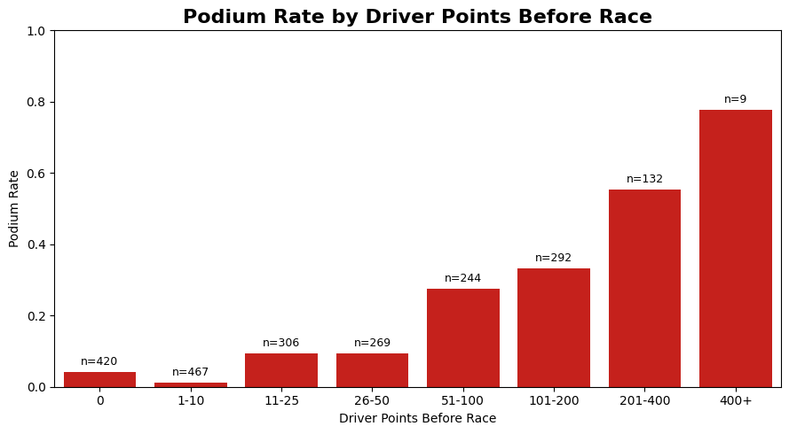

```python
points_df = df[df["year"] >= 2020].copy()

points_df["driver_points_tier"] = pd.cut(
    points_df["driver_points_before_race"],
    bins=[-1, 0, 10, 25, 50, 100, 200, 400, 600],
    labels=[
        "0",
        "1-10",
        "11-25",
        "26-50",
        "51-100",
        "101-200",
        "201-400",
        "400+"
    ]
)

points_summary = (
    points_df
    .groupby("driver_points_tier", observed=True)
    .agg(
        starts=("podium", "count"),
        podium_rate=("podium", "mean"),
        avg_points=("driver_points_before_race", "mean")
    )
    .reset_index()
)

plt.figure(figsize=(9, 5))

sns.barplot(
    data=points_summary,
    x="driver_points_tier",
    y="podium_rate",
    color="#E10600"
)

plt.title("Podium Rate by Driver Points Before Race", fontsize=16, weight="bold")
plt.xlabel("Driver Points Before Race")
plt.ylabel("Podium Rate")
plt.ylim(0, 1)

for i, row in points_summary.iterrows():
    plt.text(
        i,
        row["podium_rate"] + 0.02,
        f'n={row["starts"]}',
        ha="center",
        fontsize=9
    )

plt.tight_layout()
plt.show()
```

This plot shows that drivers with more points before a race are much more likely to finish on the podium. Drivers with 0 or 1–10 points before a race have very low podium rates, while drivers with 201–400 points have a podium rate above 50%.

Overall, this supports using `driver_points_before_race` as a predictor because it captures current-season driver performance before the race begins. However, the sample sizes shown above the bars also show that very high point totals are rare, so the model should not rely only on this variable.

#### Checks for Bahrain 2024 GP

```python
bahrain_2024 = df[(df["year"] == 2024) & (df["round"] == 1)].copy()

bahrain_check_cols = [
    "raceId",
    "year",
    "round",
    "circuit_name",
    "date",
    "driverId",
    "forename",
    "surname",
    "constructorId",
    "constructor_name",
    "grid",
    "qualifying_position",

    # before-race season standings
    "driver_points_before_race",
    "driver_standing_before_race",
    "driver_wins_before_race",

    # driver same-circuit history
    "driver_circuit_avg_finish_last5",
    "driver_circuit_podium_rate_last5",
    "driver_circuit_avg_points_last5",

    # driver race history regardless of circuit
    "driver_recent_avg_finish_last5",
    "driver_recent_podium_rate_last5",
    "driver_recent_avg_points_last5",

    # outcome columns
    "positionOrder",
    "positionText",
    "points",
    "podium",
    "status"
]

bahrain_2024[bahrain_check_cols].sort_values("positionOrder")
```

|  | raceId | year | round | circuit_name | date | driverId | forename | surname | constructorId | constructor_name | grid | qualifying_position | driver_points_before_race | driver_standing_before_race | driver_wins_before_race | driver_circuit_avg_finish_last5 | driver_circuit_podium_rate_last5 | driver_circuit_avg_points_last5 | driver_recent_avg_finish_last5 | driver_recent_podium_rate_last5 | driver_recent_avg_points_last5 | positionOrder | positionText | points | podium | status |
| --- | --- | --- | --- | --- | --- | --- | --- | --- | --- | --- | --- | --- | --- | --- | --- | --- | --- | --- | --- | --- | --- | --- | --- | --- | --- | --- |
| 24838 | 1121 | 2024 | 1 | Bahrain International Circuit | 2024-03-02 | 830 | Max | Verstappen | 9 | Red Bull | 1 | 1.0 | 0.0 | 99.0 | 0.0 | 8.600000 | 0.6 | 12.4 | 1.0 | 1.0 | 25.2 | 1 | 1 | 26.0 | 1 | Finished |
| 23446 | 1121 | 2024 | 1 | Bahrain International Circuit | 2024-03-02 | 815 | Sergio | Pérez | 9 | Red Bull | 5 | 5.0 | 0.0 | 99.0 | 0.0 | 8.800000 | 0.4 | 10.6 | 7.0 | 0.2 | 10.2 | 2 | 2 | 18.0 | 1 | Finished |
| 25087 | 1121 | 2024 | 1 | Bahrain International Circuit | 2024-03-02 | 832 | Carlos | Sainz | 6 | Ferrari | 4 | 4.0 | 0.0 | 99.0 | 0.0 | 4.600000 | 0.2 | 11.2 | 7.4 | 0.2 | 8.6 | 3 | 3 | 15.0 | 1 | Finished |
| 25948 | 1121 | 2024 | 1 | Bahrain International Circuit | 2024-03-02 | 844 | Charles | Leclerc | 6 | Ferrari | 2 | 2.0 | 0.0 | 99.0 | 0.0 | 11.200000 | 0.2 | 7.0 | 9.4 | 0.6 | 10.2 | 4 | 4 | 12.0 | 0 | Finished |
| 26225 | 1121 | 2024 | 1 | Bahrain International Circuit | 2024-03-02 | 847 | George | Russell | 131 | Mercedes | 3 | 3.0 | 0.0 | 99.0 | 0.0 | 9.200000 | 0.0 | 4.2 | 7.4 | 0.2 | 7.4 | 5 | 5 | 10.0 | 0 | Finished |
| 26097 | 1121 | 2024 | 1 | Bahrain International Circuit | 2024-03-02 | 846 | Lando | Norris | 1 | McLaren | 7 | 7.0 | 0.0 | 99.0 | 0.0 | 10.000000 | 0.0 | 5.0 | 6.8 | 0.4 | 11.4 | 6 | 6 | 8.0 | 0 | Finished |
| 332 | 1121 | 2024 | 1 | Bahrain International Circuit | 2024-03-02 | 1 | Lewis | Hamilton | 131 | Mercedes | 9 | 9.0 | 0.0 | 99.0 | 0.0 | 2.200000 | 0.8 | 20.0 | 9.0 | 0.2 | 6.2 | 7 | 7 | 6.0 | 0 | Finished |
| 26675 | 1121 | 2024 | 1 | Bahrain International Circuit | 2024-03-02 | 857 | Oscar | Piastri | 1 | McLaren | 8 | 8.0 | 0.0 | 99.0 | 0.0 | 20.000000 | 0.0 | 0.0 | 11.0 | 0.0 | 2.8 | 8 | 8 | 4.0 | 0 | Finished |
| 1126 | 1121 | 2024 | 1 | Bahrain International Circuit | 2024-03-02 | 4 | Fernando | Alonso | 117 | Aston Martin | 6 | 6.0 | 0.0 | 99.0 | 0.0 | 10.400000 | 0.2 | 4.6 | 10.6 | 0.2 | 4.6 | 9 | 9 | 2.0 | 0 | Finished |
| 25558 | 1121 | 2024 | 1 | Bahrain International Circuit | 2024-03-02 | 840 | Lance | Stroll | 117 | Aston Martin | 12 | 12.0 | 0.0 | 99.0 | 0.0 | 10.000000 | 0.2 | 4.8 | 8.8 | 0.0 | 5.4 | 10 | 10 | 1.0 | 0 | Finished |
| 26618 | 1121 | 2024 | 1 | Bahrain International Circuit | 2024-03-02 | 855 | Guanyu | Zhou | 15 | Sauber | 17 | 17.0 | 0.0 | 99.0 | 0.0 | 13.000000 | 0.0 | 0.5 | 15.2 | 0.0 | 0.0 | 11 | 11 | 0.0 | 0 | +1 Lap |
| 24402 | 1121 | 2024 | 1 | Bahrain International Circuit | 2024-03-02 | 825 | Kevin | Magnussen | 210 | Haas F1 Team | 15 | 15.0 | 0.0 | 99.0 | 0.0 | 12.600000 | 0.0 | 2.0 | 16.8 | 0.0 | 0.0 | 12 | 12 | 0.0 | 0 | +1 Lap |
| 23729 | 1121 | 2024 | 1 | Bahrain International Circuit | 2024-03-02 | 817 | Daniel | Ricciardo | 215 | RB F1 Team | 14 | 14.0 | 0.0 | 99.0 | 0.0 | 10.200000 | 0.0 | 4.4 | 12.0 | 0.0 | 1.2 | 13 | 13 | 0.0 | 0 | +1 Lap |
| 26484 | 1121 | 2024 | 1 | Bahrain International Circuit | 2024-03-02 | 852 | Yuki | Tsunoda | 215 | RB F1 Team | 11 | 11.0 | 0.0 | 99.0 | 0.0 | 9.333333 | 0.0 | 2.0 | 11.0 | 0.0 | 2.2 | 14 | 14 | 0.0 | 0 | +1 Lap |
| 26330 | 1121 | 2024 | 1 | Bahrain International Circuit | 2024-03-02 | 848 | Alexander | Albon | 3 | Williams | 13 | 13.0 | 0.0 | 99.0 | 0.0 | 8.200000 | 0.2 | 5.2 | 12.6 | 0.0 | 0.8 | 15 | 15 | 0.0 | 0 | +1 Lap |
| 22874 | 1121 | 2024 | 1 | Bahrain International Circuit | 2024-03-02 | 807 | Nico | Hülkenberg | 210 | Haas F1 Team | 10 | 10.0 | 0.0 | 99.0 | 0.0 | 12.800000 | 0.0 | 2.0 | 14.0 | 0.0 | 0.0 | 16 | 16 | 0.0 | 0 | +1 Lap |
| 25391 | 1121 | 2024 | 1 | Bahrain International Circuit | 2024-03-02 | 839 | Esteban | Ocon | 214 | Alpine F1 Team | 19 | 19.0 | 0.0 | 99.0 | 0.0 | 9.800000 | 0.2 | 5.2 | 10.8 | 0.0 | 2.8 | 17 | 17 | 0.0 | 0 | +1 Lap |
| 25774 | 1121 | 2024 | 1 | Bahrain International Circuit | 2024-03-02 | 842 | Pierre | Gasly | 214 | Alpine F1 Team | 20 | 20.0 | 0.0 | 99.0 | 0.0 | 12.600000 | 0.0 | 2.0 | 9.6 | 0.0 | 2.8 | 18 | 18 | 0.0 | 0 | +1 Lap |
| 24161 | 1121 | 2024 | 1 | Bahrain International Circuit | 2024-03-02 | 822 | Valtteri | Bottas | 15 | Sauber | 16 | 16.0 | 0.0 | 99.0 | 0.0 | 6.600000 | 0.2 | 7.2 | 15.8 | 0.0 | 0.0 | 19 | 19 | 0.0 | 0 | +1 Lap |
| 26721 | 1121 | 2024 | 1 | Bahrain International Circuit | 2024-03-02 | 858 | Logan | Sargeant | 3 | Williams | 18 | 18.0 | 0.0 | 99.0 | 0.0 | 12.000000 | 0.0 | 0.0 | 13.8 | 0.0 | 0.2 | 20 | 20 | 0.0 | 0 | +2 Laps |

## Target Variable

```python
df["podium"] = (df["positionOrder"] <= 3).astype(int)

df["podium_place"] = np.where(
    df["positionOrder"] <= 3,
    df["positionOrder"],
    np.nan
)
```

```python
df["podium"].value_counts()
df["podium"].value_counts(normalize=True)
```

```
podium
0    0.873052
1    0.126948
Name: proportion, dtype: float64
```

```python
df.to_csv("../data/processed/before_race_merged_dataset.csv", index=False)
```

## Create the modeling dataset

```python
df = pd.read_csv("../data/processed/before_race_merged_dataset.csv", low_memory=False)

modeling_data = df[[

    #identifiers / labels, not predictors
    "raceId",
    "driverId",
    "forename",
    "surname",
    "constructorId",
    "constructor_name",
    "circuitId",
    "circuit_name",
    "year",
    "round",

    #pre race predictors
    "grid",
    "qualifying_position",

    "driver_points_before_race",
    "driver_standing_before_race",
    "driver_wins_before_race",

    "constructor_points_before_race",
    "constructor_standing_before_race",
    "constructor_wins_before_race",

    #driver circuit history
    "driver_circuit_avg_finish_last5",
    "driver_circuit_podium_rate_last5",
    "driver_circuit_avg_points_last5",

    #driver recent histry, regardless of circuit
    "driver_recent_avg_finish_last5",
    "driver_recent_podium_rate_last5",
    "driver_recent_avg_points_last5",


    #outcome columns, not predictors
    "positionOrder",
    "podium"
]].copy()

modeling_data.head()
```

|  | raceId | driverId | forename | surname | constructorId | constructor_name | circuitId | circuit_name | year | round | grid | qualifying_position | driver_points_before_race | driver_standing_before_race | driver_wins_before_race | constructor_points_before_race | constructor_standing_before_race | constructor_wins_before_race | driver_circuit_avg_finish_last5 | driver_circuit_podium_rate_last5 | driver_circuit_avg_points_last5 | driver_recent_avg_finish_last5 | driver_recent_podium_rate_last5 | driver_recent_avg_points_last5 | positionOrder | podium |
| --- | --- | --- | --- | --- | --- | --- | --- | --- | --- | --- | --- | --- | --- | --- | --- | --- | --- | --- | --- | --- | --- | --- | --- | --- | --- | --- |
| 0 | 833 | 579 | Juan | Fangio | 51 | Alfa Romeo | 9 | Silverstone Circuit | 1950 | 1 | 3 | NaN | 0.0 | 99.0 | 0.0 | 0.0 | 99.0 | 0.0 | 0.0 | 0.0 | 0.0 | NaN | NaN | NaN | 12 | 0 |
| 1 | 833 | 589 | Louis | Chiron | 105 | Maserati | 9 | Silverstone Circuit | 1950 | 1 | 11 | NaN | 0.0 | 99.0 | 0.0 | 0.0 | 99.0 | 0.0 | 0.0 | 0.0 | 0.0 | NaN | NaN | NaN | 18 | 0 |
| 2 | 833 | 619 | Bob | Gerard | 151 | ERA | 9 | Silverstone Circuit | 1950 | 1 | 13 | NaN | 0.0 | 99.0 | 0.0 | 0.0 | 99.0 | 0.0 | 0.0 | 0.0 | 0.0 | NaN | NaN | NaN | 6 | 0 |
| 3 | 833 | 627 | Louis | Rosier | 154 | Talbot-Lago | 9 | Silverstone Circuit | 1950 | 1 | 9 | NaN | 0.0 | 99.0 | 0.0 | 0.0 | 99.0 | 0.0 | 0.0 | 0.0 | 0.0 | NaN | NaN | NaN | 5 | 0 |
| 4 | 833 | 640 | Toulo | de Graffenried | 105 | Maserati | 9 | Silverstone Circuit | 1950 | 1 | 8 | NaN | 0.0 | 99.0 | 0.0 | 0.0 | 99.0 | 0.0 | 0.0 | 0.0 | 0.0 | NaN | NaN | NaN | 17 | 0 |

#### Handling missing data

```python
modeling_data.isna().sum()
```

```
raceId                                  0
driverId                                0
forename                                0
surname                                 0
constructorId                           0
constructor_name                        0
circuitId                               0
circuit_name                            0
year                                    0
round                                   0
grid                                    0
qualifying_position                 16275
driver_points_before_race               0
driver_standing_before_race             0
driver_wins_before_race                 0
constructor_points_before_race          0
constructor_standing_before_race        0
constructor_wins_before_race            0
driver_circuit_avg_finish_last5         0
driver_circuit_podium_rate_last5        0
driver_circuit_avg_points_last5         0
driver_recent_avg_finish_last5        861
driver_recent_podium_rate_last5       861
driver_recent_avg_points_last5        861
positionOrder                           0
podium                                  0
dtype: int64
```

Drop rows with missing qualifying position data, this is a strong predictor, so remove them

```python
#drop rows missing qualifying position
modeling_data = modeling_data.dropna(subset=["qualifying_position"]).copy()

#fill missing recent driver history
modeling_data["driver_recent_avg_finish_last5"] = modeling_data["driver_recent_avg_finish_last5"].fillna(99)
modeling_data["driver_recent_podium_rate_last5"] = modeling_data["driver_recent_podium_rate_last5"].fillna(0)
modeling_data["driver_recent_avg_points_last5"] = modeling_data["driver_recent_avg_points_last5"].fillna(0)

#fill missing circuit history
modeling_data["driver_circuit_avg_finish_last5"] = modeling_data["driver_circuit_avg_finish_last5"].fillna(99)
modeling_data["driver_circuit_podium_rate_last5"] = modeling_data["driver_circuit_podium_rate_last5"].fillna(0)
modeling_data["driver_circuit_avg_points_last5"] = modeling_data["driver_circuit_avg_points_last5"].fillna(0)
```

```python
#save modeling dataset
modeling_data.to_csv("../data/processed/f1_modeling_dataset.csv", index=False)
```

## Predictor Coorelation Plot

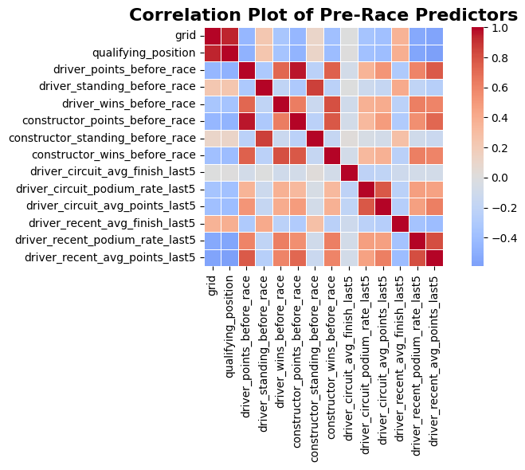

```python
predictor_cols = [
    "grid",
    "qualifying_position",
    "driver_points_before_race",
    "driver_standing_before_race",
    "driver_wins_before_race",
    "constructor_points_before_race",
    "constructor_standing_before_race",
    "constructor_wins_before_race",
    "driver_circuit_avg_finish_last5",
    "driver_circuit_podium_rate_last5",
    "driver_circuit_avg_points_last5",
    "driver_recent_avg_finish_last5",
    "driver_recent_podium_rate_last5",
    "driver_recent_avg_points_last5"
]

# only keep columns that actually exist
predictor_cols = [col for col in predictor_cols if col in modeling_data.columns]

corr = modeling_data[predictor_cols].corr()

plt.figure(figsize=(9, 6))

sns.heatmap(
    corr,
    cmap="coolwarm",
    center=0,
    linewidths=0.5,
    square=True
)


plt.title("Correlation Plot of Pre-Race Predictors", fontsize=16, weight="bold")
plt.tight_layout()
plt.show()
```

## Setting up Models

### Set Up Feature Sets

```python
feature_sets = {

    # very simple baseline
    "grid_only": [
        "grid"
    ],

    # strongest basic pre-race variables
    "grid_and_qualifying": [
        "grid",
        "qualifying_position"
    ],

    # race context only
    "race_context": [
        "grid",
        "qualifying_position",
        "year",
        "round",
        "circuitId"
    ],

    # driver/team/circuit identity
    "driver_constructor_circuit": [
        "grid",
        "qualifying_position",
        "driverId",
        "constructorId",
        "circuitId"
    ],

    # current season standings before the race
    "season_standings": [
        "grid",
        "qualifying_position",
        "driver_points_before_race",
        "driver_standing_before_race",
        "driver_wins_before_race",
        "constructor_points_before_race",
        "constructor_standing_before_race",
        "constructor_wins_before_race"
    ],

    # driver history at this exact circuit
    "driver_circuit_history": [
        "grid",
        "qualifying_position",
        "driver_circuit_avg_finish_last5",
        "driver_circuit_podium_rate_last5",
        "driver_circuit_avg_points_last5"
    ],

    # recent driver form, regardless of circuit/team
    "driver_recent_form": [
        "grid",
        "qualifying_position",
        "driver_recent_avg_finish_last5",
        "driver_recent_podium_rate_last5",
        "driver_recent_avg_points_last5"
    ],

    # season standings + circuit history
    "standings_and_circuit_history": [
        "grid",
        "qualifying_position",
        "driver_points_before_race",
        "driver_standing_before_race",
        "driver_wins_before_race",
        "constructor_points_before_race",
        "constructor_standing_before_race",
        "constructor_wins_before_race",
        "driver_circuit_avg_finish_last5",
        "driver_circuit_podium_rate_last5",
        "driver_circuit_avg_points_last5"
    ],

    # season standings + recent form
    "standings_and_recent_form": [
        "grid",
        "qualifying_position",
        "driver_points_before_race",
        "driver_standing_before_race",
        "driver_wins_before_race",
        "constructor_points_before_race",
        "constructor_standing_before_race",
        "constructor_wins_before_race",
        "driver_recent_avg_finish_last5",
        "driver_recent_podium_rate_last5",
        "driver_recent_avg_points_last5"
    ],

    # all engineered pre-race features
    "all_valid_features": [
        "driverId",
        "constructorId",
        "circuitId",
        "year",
        "round",
        "grid",
        "qualifying_position",
        "driver_points_before_race",
        "driver_standing_before_race",
        "driver_wins_before_race",
        "constructor_points_before_race",
        "constructor_standing_before_race",
        "constructor_wins_before_race",
        "driver_circuit_avg_finish_last5",
        "driver_circuit_podium_rate_last5",
        "driver_circuit_avg_points_last5",
        "driver_recent_avg_finish_last5",
        "driver_recent_podium_rate_last5",
        "driver_recent_avg_points_last5"
    ]
}
```

### Train/Test Split and Cross-Validation Setup

```python
#Chronological Train/Test Split

train = modeling_data[modeling_data["year"] <= 2021].copy()
test = modeling_data[modeling_data["year"] >= 2022].copy()

print("Train shape:", train.shape)
print("Test shape:", test.shape)

print("\nTrain podium distribution: ", train["podium"].value_counts(normalize=True))

print("\nTest podium distribution: ", test["podium"].value_counts(normalize=True))
```

```
Train shape: (9125, 26)
Test shape: (1359, 26)

Train podium distribution:  podium
0    0.859945
1    0.140055
Name: proportion, dtype: float64

Test podium distribution:  podium
0    0.84989
1    0.15011
Name: proportion, dtype: float64
```

```python
cv = StratifiedKFold(
    n_splits=5,
    shuffle=True,
    random_state=42
)
```

And in the training data, I used stratified 5-fold cross-validation. Stratification is useful because podium finishes are much less common than non-podium finishes, so each fold should keep a similar class balance.

### Define Models:

```python
models = {

    #baseline
    "Logistic Regression": make_pipeline(
        StandardScaler(),
        LogisticRegression(max_iter=5000, random_state=42)
    ),

    "Elastic Net Logistic Regression": make_pipeline(
        StandardScaler(),
        LogisticRegression(
            solver="saga",
            l1_ratio=0.5,
            C=1.0,
            max_iter=5000,
            random_state=42
        )
    ),

    "LDA": make_pipeline(
        StandardScaler(),
        LinearDiscriminantAnalysis()
    ),

    "QDA": make_pipeline(
        StandardScaler(),
        QuadraticDiscriminantAnalysis(reg_param=0.1)
    ),

    "KNN": make_pipeline(
        StandardScaler(),
        KNeighborsClassifier(n_neighbors=15)
    ),

    "Decision Tree": DecisionTreeClassifier(
        max_depth=5,
        random_state=42
    ),

    "Random Forest": RandomForestClassifier(
        n_estimators=200,
        random_state=42,
        class_weight="balanced"
    ),

    "Gradient Boosting": GradientBoostingClassifier(
        random_state=42
    )
}
```

### Test loop

```python
model_results = []
```

```python
cv_results = []

scoring = {
    "accuracy": "accuracy",
    "precision": "precision",
    "recall": "recall",
    "f1": "f1",
    "roc_auc": "roc_auc"
}

for feature_set_name, features in feature_sets.items():

    X_train = train[features]
    y_train = train["podium"]

    for model_name, model in models.items():

        scores = cross_validate(
            model,
            X_train,
            y_train,
            cv=cv,
            scoring=scoring,
            n_jobs=-1
        )

        cv_results.append({
            "feature_set": feature_set_name,
            "model": model_name,
            "accuracy": scores["test_accuracy"].mean(),
            "precision": scores["test_precision"].mean(),
            "recall": scores["test_recall"].mean(),
            "f1": scores["test_f1"].mean(),
            "roc_auc": scores["test_roc_auc"].mean()
        })

results_df = pd.DataFrame(cv_results)

results_df.sort_values("roc_auc", ascending=False).head(10)
```

|  | feature_set | model | accuracy | precision | recall | f1 | roc_auc |
| --- | --- | --- | --- | --- | --- | --- | --- |
| 79 | all_valid_features | Gradient Boosting | 0.899068 | 0.665662 | 0.561057 | 0.608800 | 0.923177 |
| 71 | standings_and_recent_form | Gradient Boosting | 0.899288 | 0.669769 | 0.555561 | 0.607097 | 0.921108 |
| 63 | standings_and_circuit_history | Gradient Boosting | 0.898630 | 0.659889 | 0.570423 | 0.611730 | 0.920222 |
| 55 | driver_recent_form | Gradient Boosting | 0.900712 | 0.671244 | 0.570414 | 0.616696 | 0.919961 |
| 73 | all_valid_features | Elastic Net Logistic Regression | 0.897753 | 0.677432 | 0.515683 | 0.585371 | 0.919541 |
| 72 | all_valid_features | Logistic Regression | 0.897534 | 0.676079 | 0.515680 | 0.584876 | 0.919516 |
| 39 | season_standings | Gradient Boosting | 0.899836 | 0.664955 | 0.574354 | 0.616235 | 0.919177 |
| 78 | all_valid_features | Random Forest | 0.895781 | 0.676838 | 0.489816 | 0.568196 | 0.918395 |
| 31 | driver_constructor_circuit | Gradient Boosting | 0.898849 | 0.665961 | 0.557151 | 0.606476 | 0.918219 |
| 64 | standings_and_recent_form | Logistic Regression | 0.897425 | 0.680133 | 0.505512 | 0.579807 | 0.917776 |

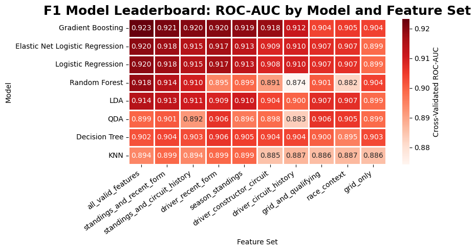

```python
import matplotlib.pyplot as plt
import seaborn as sns

model_palette = {
    "Logistic Regression": "#E10600",
    "Elastic Net Logistic Regression": "#FF8000",
    "LDA": "#27F4D2",
    "QDA": "#229971",
    "KNN": "#64C4FF",
    "Decision Tree": "#B6BABD",
    "Random Forest": "#3671C6",
    "Gradient Boosting": "#FFD700"
}

# make model x feature set table
heatmap_data = results_df.pivot_table(
    index="model",
    columns="feature_set",
    values="roc_auc"
)

# order models by their best score
model_order = (
    results_df
    .groupby("model")["roc_auc"]
    .max()
    .sort_values(ascending=False)
    .index
)

# order feature sets by their best score
feature_order = (
    results_df
    .groupby("feature_set")["roc_auc"]
    .max()
    .sort_values(ascending=False)
    .index
)

heatmap_data = heatmap_data.loc[model_order, feature_order]

plt.figure(figsize=(9, 5))

ax = sns.heatmap(
    heatmap_data,
    annot=True,
    fmt=".3f",
    cmap="Reds",
    linewidths=0.8,
    linecolor="white",
    cbar_kws={"label": "Cross-Validated ROC-AUC"}
)

plt.title("F1 Model Leaderboard: ROC-AUC by Model and Feature Set", fontsize=18, weight="bold")
plt.xlabel("Feature Set")
plt.ylabel("Model")

plt.xticks(rotation=35, ha="right")
plt.yticks(rotation=0)

plt.tight_layout()
plt.show()
```

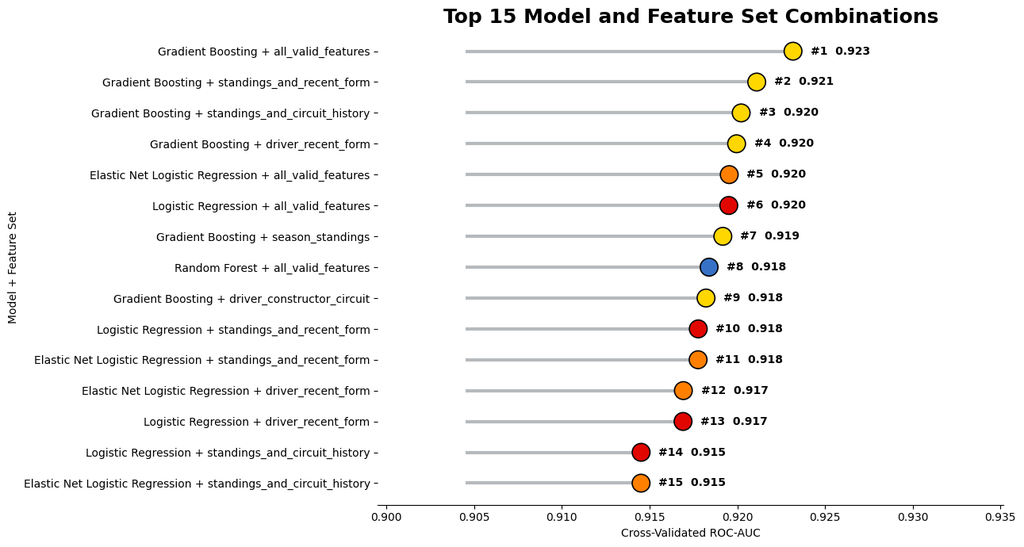

```python
top_df = results_df.sort_values("roc_auc", ascending=False).head(15).copy()
top_df["rank"] = range(1, len(top_df) + 1)
top_df["combo"] = top_df["model"] + " + " + top_df["feature_set"]

top_df = top_df.sort_values("roc_auc", ascending=True)

colors = top_df["model"].map(model_palette)

plt.figure(figsize=(13, 7))

plt.hlines(
    y=top_df["combo"],
    xmin=top_df["roc_auc"].min() - 0.01,
    xmax=top_df["roc_auc"],
    color="#B6BABD",
    linewidth=3
)

plt.scatter(
    top_df["roc_auc"],
    top_df["combo"],
    s=260,
    color=colors,
    edgecolor="black",
    linewidth=1.2,
    zorder=3
)

for _, row in top_df.iterrows():
    plt.text(
        row["roc_auc"] + 0.001,
        row["combo"],
        f'#{int(row["rank"])}  {row["roc_auc"]:.3f}',
        va="center",
        fontsize=10,
        weight="bold"
    )

plt.title("Top 15 Model and Feature Set Combinations", fontsize=18, weight="bold")
plt.xlabel("Cross-Validated ROC-AUC")
plt.ylabel("Model + Feature Set")

plt.xlim(top_df["roc_auc"].min() - 0.015, top_df["roc_auc"].max() + 0.012)

sns.despine(left=True)
plt.tight_layout()
plt.show()
```

```python
results_df.to_csv("../data/processed/model_experiment_results.csv", index=False)
```

## Model Tuning and Selection

#### Select Best Performing Model from Cross Validation

```python
best_cv_model = results_df.sort_values("roc_auc", ascending=False).iloc[0]

best_model_name = best_cv_model["model"]
best_feature_set_name = best_cv_model["feature_set"]
best_features = feature_sets[best_feature_set_name]

print("Best model from CV:", best_model_name)
print("Best feature set:", best_feature_set_name)
print("Best features:", best_features)
```

```
Best model from CV: Gradient Boosting
Best feature set: all_valid_features
Best features: ['driverId', 'constructorId', 'circuitId', 'year', 'round', 'grid', 'qualifying_position', 'driver_points_before_race', 'driver_standing_before_race', 'driver_wins_before_race', 'constructor_points_before_race', 'constructor_standing_before_race', 'constructor_wins_before_race', 'driv…
```

#### Set Up Training and Test Data

```python
X_train = train[best_features]
Y_train = train["podium"]

X_test = test[best_features]
Y_test = test["podium"]
```

### Tuning Grids

```python
tuning_models = {

    "KNN": {
        "model": make_pipeline(
            StandardScaler(),
            KNeighborsClassifier()
        ),
        "params": {
            "kneighborsclassifier__n_neighbors": [5, 10, 15, 25, 35],
            "kneighborsclassifier__weights": ["uniform", "distance"]
        }
    },

    "Decision Tree": {
        "model": DecisionTreeClassifier(random_state=42),
        "params": {
            "max_depth": [2, 3, 5, 8, 12],
            "min_samples_leaf": [1, 5, 10, 25]
        }
    },

    "Random Forest": {
        "model": RandomForestClassifier(
            random_state=42,
            class_weight="balanced"
        ),
        "params": {
            "n_estimators": [100, 200],
            "max_depth": [3, 5, 8, None],
            "min_samples_leaf": [1, 5, 10],
            "max_features": ["sqrt", "log2"]
        }
    },

    "Gradient Boosting": {
        "model": GradientBoostingClassifier(random_state=42),
        "params": {
            "n_estimators": [50, 100, 200],
            "learning_rate": [0.01, 0.05, 0.10],
            "max_depth": [1, 2, 3]
        }
    },

    "Elastic Net Logistic Regression": {
    "model": make_pipeline(
        StandardScaler(),
        LogisticRegression(
            solver="saga",
            max_iter=5000,
            random_state=42
        )
    ),
    "params": {
        "logisticregression__C": [0.01, 0.1, 1, 10],
        "logisticregression__l1_ratio": [0.1, 0.5, 0.9]
    }
}
}
```

### Tuning with Cross Validation

```python
tuned_results = []
best_tuned_models = {}

for model_name, setup in tuning_models.items():

    print("Tuning:", model_name)

    grid_search = GridSearchCV(
        estimator=setup["model"],
        param_grid=setup["params"],
        scoring="roc_auc",
        cv=cv,
        n_jobs=-1
    )

    grid_search.fit(X_train, y_train)

    best_tuned_models[model_name] = grid_search

    tuned_results.append({
        "model": model_name,
        "best_cv_roc_auc": grid_search.best_score_,
        "best_params": grid_search.best_params_
    })

tuned_results_df = pd.DataFrame(tuned_results)

tuned_results_df.sort_values("best_cv_roc_auc", ascending=False)
```

```
Tuning: KNN
Tuning: Decision Tree
Tuning: Random Forest
Tuning: Gradient Boosting
Tuning: Elastic Net Logistic Regression
```

|  | model | best_cv_roc_auc | best_params |
| --- | --- | --- | --- |
| 2 | Random Forest | 0.924731 | {'max_depth': 8, 'max_features': 'sqrt', 'min_samples_leaf': 10, 'n_estimators': 200} |
| 3 | Gradient Boosting | 0.923873 | {'learning_rate': 0.05, 'max_depth': 3, 'n_estimators': 200} |
| 4 | Elastic Net Logistic Regression | 0.920264 | {'logisticregression__C': 0.01, 'logisticregression__l1_ratio': 0.1} |
| 1 | Decision Tree | 0.906206 | {'max_depth': 5, 'min_samples_leaf': 25} |
| 0 | KNN | 0.905668 | {'kneighborsclassifier__n_neighbors': 35, 'kneighborsclassifier__weights': 'distance'} |

### Results

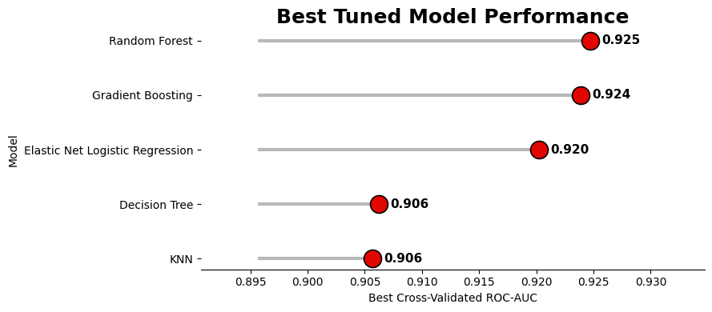

```python
plot_df = tuned_results_df.sort_values("best_cv_roc_auc", ascending=True).copy()

plt.figure(figsize=(9, 4))

# horizontal lines
plt.hlines(
    y=plot_df["model"],
    xmin=plot_df["best_cv_roc_auc"].min() - 0.01,
    xmax=plot_df["best_cv_roc_auc"],
    color="#B6BABD",
    linewidth=3
)

# dots
plt.scatter(
    plot_df["best_cv_roc_auc"],
    plot_df["model"],
    s=250,
    color="#E10600",
    edgecolor="black",
    linewidth=1.2,
    zorder=3
)

# labels
for i, row in plot_df.iterrows():
    plt.text(
        row["best_cv_roc_auc"] + 0.001,
        row["model"],
        f'{row["best_cv_roc_auc"]:.3f}',
        va="center",
        fontsize=11,
        weight="bold"
    )

plt.title("Best Tuned Model Performance", fontsize=18, weight="bold")
plt.xlabel("Best Cross-Validated ROC-AUC")
plt.ylabel("Model")
plt.xlim(plot_df["best_cv_roc_auc"].min() - 0.015, plot_df["best_cv_roc_auc"].max() + 0.01)

sns.despine(left=True, bottom=False)
plt.tight_layout()
plt.show()
```

The models with meaningful hyperparameters were tuned using 5-fold stratified cross-validation. KNN was tuned over the number of neighbors and weighting method, Decision Tree was tuned over maximum depth and minimum leaf size, Random Forest was tuned over number of trees, maximum depth, minimum leaf size, and number of features considered at each split, and Gradient Boosting was tuned over number of estimators, learning rate, and tree depth. The model with the highest cross-validated ROC-AUC was selected as the final model.

```python
tuned_results_df.to_csv("../data/processed/tuned_model_results.csv", index=False)
```

## Model Testing

Choose the best model based on cross validated ROC-AUC

```python
best_tuned_row = tuned_results_df.sort_values("best_cv_roc_auc", ascending=False).iloc[0]

best_tuned_model_name = best_tuned_row["model"]
best_tuned_model = best_tuned_model = best_tuned_models[best_tuned_model_name].best_estimator_

print("Best tuned model:", best_tuned_model_name)
print("Best CV ROC-AUC:", best_tuned_row["best_cv_roc_auc"])
print("Best parameters:", best_tuned_row["best_params"])
```

```
Best tuned model: Random Forest
Best CV ROC-AUC: 0.9247306586466169
Best parameters: {'max_depth': 8, 'max_features': 'sqrt', 'min_samples_leaf': 10, 'n_estimators': 200}
```

```python
X_train = train[best_features]
Y_train = train["podium"]

X_test = test[best_features]
Y_test = test["podium"]

#fit model on full training set
best_tuned_model.fit(X_train, Y_train)

#predictions
Y_pred = best_tuned_model.predict(X_test)
Y_prob = best_tuned_model.predict_proba(X_test)[:, 1]

#test metrics
test_results = pd.DataFrame({
    "model": [best_tuned_model_name],
    "feature_set": [best_feature_set_name],
    "test_accuracy": [accuracy_score(Y_test, Y_pred)],
    "test_error": [1 - accuracy_score(Y_test, Y_pred)],
    "test_precision": [precision_score(Y_test, Y_pred)],
    "test_recall": [recall_score(Y_test, Y_pred)],
    "test_f1": [f1_score(Y_test, Y_pred)],
    "test_roc_auc": [roc_auc_score(Y_test, Y_prob)]
})

test_results
```

|  | model | feature_set | test_accuracy | test_error | test_precision | test_recall | test_f1 | test_roc_auc |
| --- | --- | --- | --- | --- | --- | --- | --- | --- |
| 0 | Random Forest | all_valid_features | 0.862399 | 0.137601 | 0.525223 | 0.867647 | 0.654344 | 0.936279 |

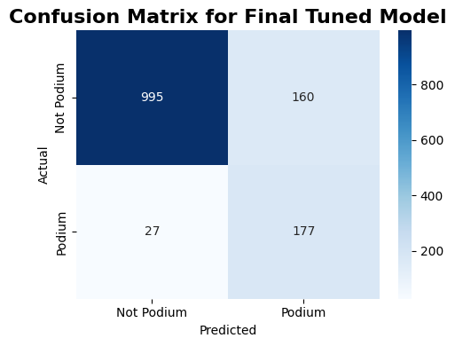

```python
cm = confusion_matrix(Y_test, Y_pred)

plt.figure(figsize=(5, 4))

sns.heatmap(
    cm,
    annot=True,
    fmt="d",
    cmap="Blues",
    xticklabels=["Not Podium", "Podium"],
    yticklabels=["Not Podium", "Podium"]
)

plt.title("Confusion Matrix for Final Tuned Model", fontsize=16, weight="bold")
plt.xlabel("Predicted")
plt.ylabel("Actual")
plt.tight_layout()
plt.show()
```

## Podium per Race Test

```python
test_predictions = test[[
    "raceId",
    "year",
    "round",
    "forename",
    "surname",
    "constructor_name",
    "positionOrder",
    "podium"
]].copy()

test_predictions["predicted_podium_probability"] = Y_prob

#rank drivers within each race by predicted podium probability
test_predictions["predicted_rank_in_race"] = (
    test_predictions
    .groupby("raceId")["predicted_podium_probability"]
    .rank(ascending=False, method="first")
)

#top 3 predicted drivers are the predicted podium
test_predictions["predicted_podium_top3"] = np.where(
    test_predictions["predicted_rank_in_race"] <= 3,
    1,
    0
)

test_predictions.head()
```

|  | raceId | year | round | forename | surname | constructor_name | positionOrder | podium | predicted_podium_probability | predicted_rank_in_race | predicted_podium_top3 |
| --- | --- | --- | --- | --- | --- | --- | --- | --- | --- | --- | --- |
| 25400 | 1074 | 2022 | 1 | Lewis | Hamilton | Mercedes | 3 | 1 | 0.749125 | 4.0 | 0 |
| 25401 | 1074 | 2022 | 1 | Fernando | Alonso | Alpine F1 Team | 9 | 0 | 0.172356 | 9.0 | 0 |
| 25402 | 1074 | 2022 | 1 | Nico | Hülkenberg | Aston Martin | 17 | 0 | 0.018913 | 18.0 | 0 |
| 25403 | 1074 | 2022 | 1 | Sergio | Pérez | Red Bull | 18 | 0 | 0.619904 | 5.0 | 0 |
| 25404 | 1074 | 2022 | 1 | Daniel | Ricciardo | McLaren | 14 | 0 | 0.034313 | 15.0 | 0 |

```python
correct_podium_predictions = (
    (test_predictions["podium"] == 1) &
    (test_predictions["predicted_podium_top3"] == 1)
).sum()

total_actual_podiums = test_predictions["podium"].sum()

podium_hit_rate = correct_podium_predictions / total_actual_podiums

print("Correct podium predictions:", correct_podium_predictions)
print("Total actual podiums:", total_actual_podiums)
print("Podium hit rate:", podium_hit_rate)
```

```
Correct podium predictions: 133
Total actual podiums: 204
Podium hit rate: 0.6519607843137255
```

```python
race_level_results = (
    test_predictions
    .groupby(["raceId", "year", "round"])
    .apply(lambda x: ((x["podium"] == 1) & (x["predicted_podium_top3"] == 1)).sum())
    .reset_index(name="correct_podiums_predicted")
)

race_level_results.head()
```

|  | raceId | year | round | correct_podiums_predicted |
| --- | --- | --- | --- | --- |
| 0 | 1074 | 2022 | 1 | 2 |
| 1 | 1075 | 2022 | 2 | 3 |
| 2 | 1076 | 2022 | 3 | 1 |
| 3 | 1077 | 2022 | 4 | 1 |
| 4 | 1078 | 2022 | 5 | 3 |

```python
print("Average correct podiums per race: ", race_level_results["correct_podiums_predicted"].mean())

print("\nDistribution of correct podium predictions per race:")
print(race_level_results["correct_podiums_predicted"].value_counts().sort_index())
```

```
Average correct podiums per race:  1.9558823529411764

Distribution of correct podium predictions per race:
correct_podiums_predicted
0     1
1    15
2    38
3    14
Name: count, dtype: int64
```

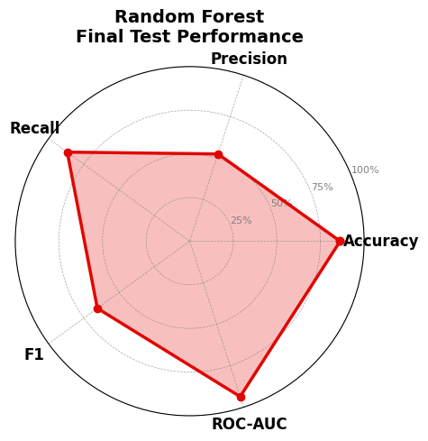

```python
#radar plot using actual final model test results

metrics = ["Accuracy", "Precision", "Recall", "F1", "ROC-AUC"]

values = [
    test_results["test_accuracy"].iloc[0],
    test_results["test_precision"].iloc[0],
    test_results["test_recall"].iloc[0],
    test_results["test_f1"].iloc[0],
    test_results["test_roc_auc"].iloc[0]
]

angles = np.linspace(0, 2 * np.pi, len(metrics), endpoint=False).tolist()

values_plot = values + [values[0]]
angles_plot = angles + [angles[0]]

fig, ax = plt.subplots(figsize=(5, 5), subplot_kw=dict(polar=True))

ax.plot(
    angles_plot,
    values_plot,
    "o-",
    linewidth=2.5,
    color="#E10600"
)

ax.fill(
    angles_plot,
    values_plot,
    alpha=0.25,
    color="#E10600"
)

ax.set_xticks(angles)
ax.set_xticklabels(metrics, fontsize=12, fontweight="bold")

ax.set_ylim(0, 1)
ax.set_yticks([0.25, 0.5, 0.75, 1.0])
ax.set_yticklabels(["25%", "50%", "75%", "100%"], fontsize=8, color="grey")

ax.set_title(
    f"{best_tuned_model_name}\nFinal Test Performance",
    fontsize=14,
    fontweight="bold",
    pad=20
)

ax.grid(color="grey", linestyle="--", linewidth=0.5, alpha=0.7)

plt.tight_layout()
plt.show()
```

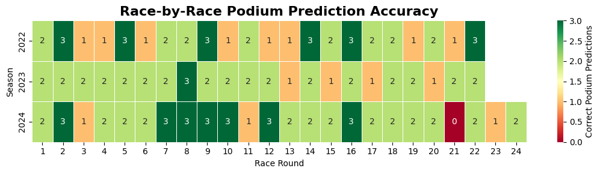

```python
heatmap_data = race_level_results.pivot(
    index="year",
    columns="round",
    values="correct_podiums_predicted"
)

plt.figure(figsize=(11, 3))

sns.heatmap(
    heatmap_data,
    annot=True,
    fmt=".0f",
    cmap="RdYlGn",
    linewidths=0.5,
    linecolor="white",
    cbar_kws={"label": "Correct Podium Predictions"}
)

plt.title("Race-by-Race Podium Prediction Accuracy",
          fontsize=16, weight="bold")
plt.xlabel("Race Round")
plt.ylabel("Season")

plt.tight_layout()
plt.show()
```

```python
from matplotlib.patches import Patch

def plot_race_predictions(year, round_num, race_name):

    one_race = (
        test_predictions[(test_predictions["year"] == year) & (test_predictions["round"] == round_num)]
        .sort_values("predicted_podium_probability", ascending=False)
        .head(10)
        .copy()
    )

    one_race["driver_name"] = one_race["forename"] + " " + one_race["surname"]

    colors = one_race["predicted_podium_top3"].map({
        1: "#E10600",
        0: "#B6BABD"
    })

    plt.figure(figsize=(9, 5))

    plt.barh(
        one_race["driver_name"],
        one_race["predicted_podium_probability"],
        color=colors,
        edgecolor="black",
        linewidth=1
    )

    plt.gca().invert_yaxis()

    #star actual podium finishers
    for position, (_, row) in enumerate(one_race.iterrows()):
        if row["podium"] == 1:
            plt.text(
                row["predicted_podium_probability"] + 0.015,
                position,
                "★ Actual Podium",
                va="center",
                fontsize=10,
                weight="bold",
                color="#FFD700"
            )

    plt.title(f"Top Predicted Podium Contenders for {race_name}",
              fontsize=16, weight="bold")
    plt.xlabel("Predicted Podium Probability")
    plt.ylabel("Driver")

    legend_items = [
        Patch(facecolor="#E10600", edgecolor="black", label="Model Predicted Top 3"),
        Patch(facecolor="#B6BABD", edgecolor="black", label="Outside Predicted Top 3"),
    ]

    plt.legend(handles=legend_items, title="Legend", loc="lower right")

    sns.despine()
    plt.tight_layout()
    plt.show()
```

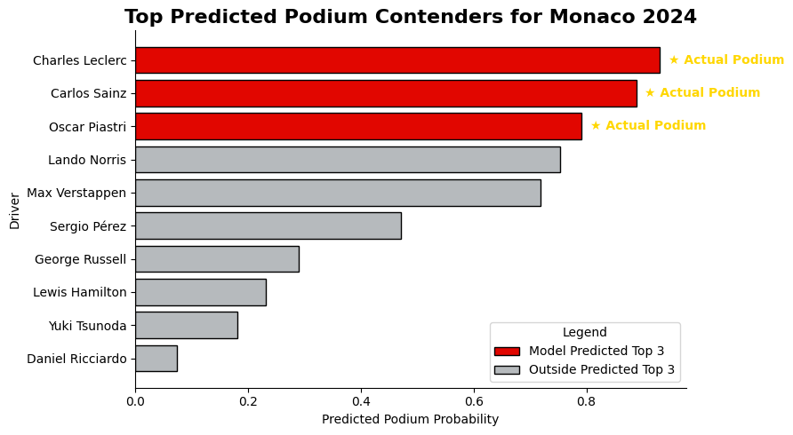

```python
plot_race_predictions(2024, 8, "Monaco 2024")
```

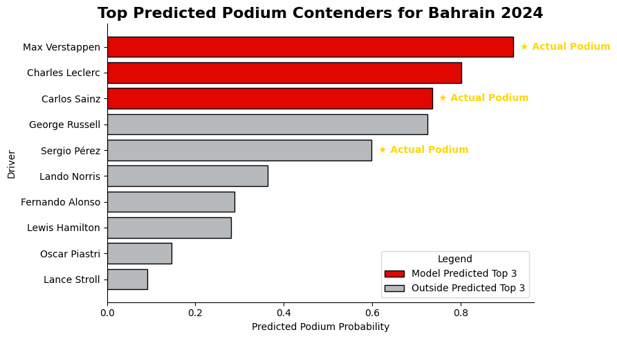

```python
plot_race_predictions(2024, 1, "Bahrain 2024")
```

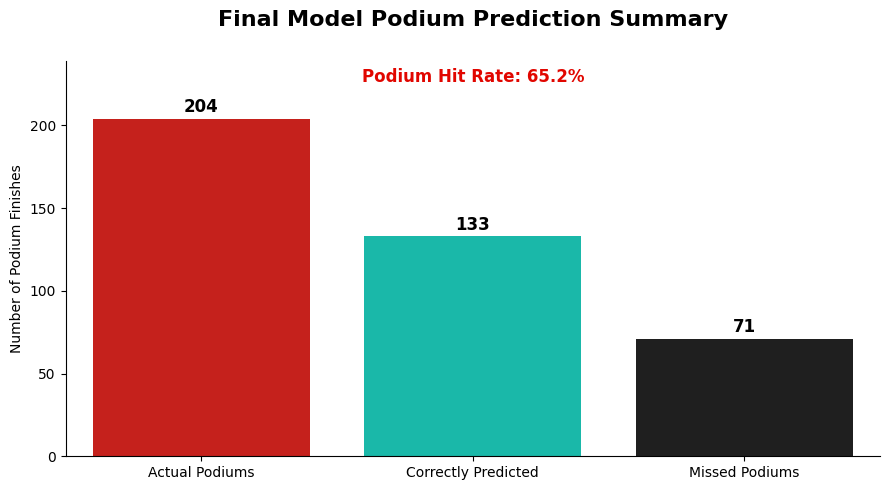

```python
correct = correct_podium_predictions
missed = total_actual_podiums - correct
hit_rate_percent = (correct / total_actual_podiums) * 100

summary_counts = pd.DataFrame({
    "Category": ["Actual Podiums", "Correctly Predicted", "Missed Podiums"],
    "Count": [total_actual_podiums, correct, missed]
})

plt.figure(figsize=(9, 5))

sns.barplot(
    data=summary_counts,
    x="Category",
    y="Count",
    hue="Category",
    palette=["#E10600", "#00D2BE", "#1F1F1F"],
    legend=False
)

plt.title(
    "Final Model Podium Prediction Summary",
    fontsize=16,
    weight="bold",
    pad=25
)

plt.text(
    1,
    max(summary_counts["Count"]) + 22,
    f"Podium Hit Rate: {hit_rate_percent:.1f}%",
    ha="center",
    fontsize=12,
    weight="bold",
    color="#E10600"
)

plt.xlabel("")
plt.ylabel("Number of Podium Finishes")

for i, row in summary_counts.iterrows():
    plt.text(
        i,
        row["Count"] + 4,
        int(row["Count"]),
        ha="center",
        fontsize=12,
        weight="bold"
    )

plt.ylim(0, max(summary_counts["Count"]) + 35)

sns.despine()
plt.tight_layout()
plt.show()
```